# Risk Factor Analysis

## Outcome Variable

**Outcome Variable:** swasted

## Predictor Variables

**Intervention Variable:** vagbrth

**Adjustment Set:**

unadjusted

## Stratifying Variables

The analysis was stratified on these variable(s):

- agecat
- studyid
- country

## Data Summary

| agecat | studyid | country | vagbrth | swasted | n_cell | n |
| --- | --- | --- | --- | --- | --- | --- |
| Birth | CMC-V-BCS-2002 | INDIA | 0 | 0 | 10 | 86 |
| Birth | CMC-V-BCS-2002 | INDIA | 0 | 1 | 0 | 86 |
| Birth | CMC-V-BCS-2002 | INDIA | 1 | 0 | 75 | 86 |
| Birth | CMC-V-BCS-2002 | INDIA | 1 | 1 | 1 | 86 |
| Birth | IRC | INDIA | 0 | 0 | 52 | 343 |
| Birth | IRC | INDIA | 0 | 1 | 14 | 343 |
| Birth | IRC | INDIA | 1 | 0 | 237 | 343 |
| Birth | IRC | INDIA | 1 | 1 | 40 | 343 |
| Birth | NIH-Crypto | BANGLADESH | 0 | 0 | 179 | 465 |
| Birth | NIH-Crypto | BANGLADESH | 0 | 1 | 5 | 465 |
| Birth | NIH-Crypto | BANGLADESH | 1 | 0 | 257 | 465 |
| Birth | NIH-Crypto | BANGLADESH | 1 | 1 | 24 | 465 |
| Birth | PROBIT | BELARUS | 0 | 0 | 1499 | 13817 |
| Birth | PROBIT | BELARUS | 0 | 1 | 92 | 13817 |
| Birth | PROBIT | BELARUS | 1 | 0 | 11399 | 13817 |
| Birth | PROBIT | BELARUS | 1 | 1 | 827 | 13817 |
| Birth | PROVIDE | BANGLADESH | 0 | 0 | 104 | 532 |
| Birth | PROVIDE | BANGLADESH | 0 | 1 | 4 | 532 |
| Birth | PROVIDE | BANGLADESH | 1 | 0 | 415 | 532 |
| Birth | PROVIDE | BANGLADESH | 1 | 1 | 9 | 532 |
| Birth | ZVITAMBO | ZIMBABWE | 0 | 0 | 1016 | 12814 |
| Birth | ZVITAMBO | ZIMBABWE | 0 | 1 | 84 | 12814 |
| Birth | ZVITAMBO | ZIMBABWE | 1 | 0 | 11011 | 12814 |
| Birth | ZVITAMBO | ZIMBABWE | 1 | 1 | 703 | 12814 |
| 6 months | CMC-V-BCS-2002 | INDIA | 0 | 0 | 25 | 368 |
| 6 months | CMC-V-BCS-2002 | INDIA | 0 | 1 | 0 | 368 |
| 6 months | CMC-V-BCS-2002 | INDIA | 1 | 0 | 331 | 368 |
| 6 months | CMC-V-BCS-2002 | INDIA | 1 | 1 | 12 | 368 |
| 6 months | IRC | INDIA | 0 | 0 | 64 | 408 |
| 6 months | IRC | INDIA | 0 | 1 | 4 | 408 |
| 6 months | IRC | INDIA | 1 | 0 | 322 | 408 |
| 6 months | IRC | INDIA | 1 | 1 | 18 | 408 |
| 6 months | NIH-Crypto | BANGLADESH | 0 | 0 | 187 | 457 |
| 6 months | NIH-Crypto | BANGLADESH | 0 | 1 | 0 | 457 |
| 6 months | NIH-Crypto | BANGLADESH | 1 | 0 | 270 | 457 |
| 6 months | NIH-Crypto | BANGLADESH | 1 | 1 | 0 | 457 |
| 6 months | PROBIT | BELARUS | 0 | 0 | 1795 | 15757 |
| 6 months | PROBIT | BELARUS | 0 | 1 | 2 | 15757 |
| 6 months | PROBIT | BELARUS | 1 | 0 | 13953 | 15757 |
| 6 months | PROBIT | BELARUS | 1 | 1 | 7 | 15757 |
| 6 months | PROVIDE | BANGLADESH | 0 | 0 | 139 | 603 |
| 6 months | PROVIDE | BANGLADESH | 0 | 1 | 0 | 603 |
| 6 months | PROVIDE | BANGLADESH | 1 | 0 | 459 | 603 |
| 6 months | PROVIDE | BANGLADESH | 1 | 1 | 5 | 603 |
| 6 months | TanzaniaChild2 | TANZANIA, UNITED REPUBLIC OF | 0 | 0 | 187 | 2004 |
| 6 months | TanzaniaChild2 | TANZANIA, UNITED REPUBLIC OF | 0 | 1 | 2 | 2004 |
| 6 months | TanzaniaChild2 | TANZANIA, UNITED REPUBLIC OF | 1 | 0 | 1805 | 2004 |
| 6 months | TanzaniaChild2 | TANZANIA, UNITED REPUBLIC OF | 1 | 1 | 10 | 2004 |
| 6 months | ZVITAMBO | ZIMBABWE | 0 | 0 | 716 | 8437 |
| 6 months | ZVITAMBO | ZIMBABWE | 0 | 1 | 5 | 8437 |
| 6 months | ZVITAMBO | ZIMBABWE | 1 | 0 | 7643 | 8437 |
| 6 months | ZVITAMBO | ZIMBABWE | 1 | 1 | 73 | 8437 |
| 24 months | CMC-V-BCS-2002 | INDIA | 0 | 0 | 25 | 372 |
| 24 months | CMC-V-BCS-2002 | INDIA | 0 | 1 | 0 | 372 |
| 24 months | CMC-V-BCS-2002 | INDIA | 1 | 0 | 344 | 372 |
| 24 months | CMC-V-BCS-2002 | INDIA | 1 | 1 | 3 | 372 |
| 24 months | IRC | INDIA | 0 | 0 | 67 | 409 |
| 24 months | IRC | INDIA | 0 | 1 | 2 | 409 |
| 24 months | IRC | INDIA | 1 | 0 | 337 | 409 |
| 24 months | IRC | INDIA | 1 | 1 | 3 | 409 |
| 24 months | NIH-Crypto | BANGLADESH | 0 | 0 | 98 | 260 |
| 24 months | NIH-Crypto | BANGLADESH | 0 | 1 | 1 | 260 |
| 24 months | NIH-Crypto | BANGLADESH | 1 | 0 | 160 | 260 |
| 24 months | NIH-Crypto | BANGLADESH | 1 | 1 | 1 | 260 |
| 24 months | PROBIT | BELARUS | 0 | 0 | 463 | 3970 |
| 24 months | PROBIT | BELARUS | 0 | 1 | 0 | 3970 |
| 24 months | PROBIT | BELARUS | 1 | 0 | 3500 | 3970 |
| 24 months | PROBIT | BELARUS | 1 | 1 | 7 | 3970 |
| 24 months | PROVIDE | BANGLADESH | 0 | 0 | 135 | 579 |
| 24 months | PROVIDE | BANGLADESH | 0 | 1 | 2 | 579 |
| 24 months | PROVIDE | BANGLADESH | 1 | 0 | 435 | 579 |
| 24 months | PROVIDE | BANGLADESH | 1 | 1 | 7 | 579 |
| 24 months | TanzaniaChild2 | TANZANIA, UNITED REPUBLIC OF | 0 | 0 | 2 | 6 |
| 24 months | TanzaniaChild2 | TANZANIA, UNITED REPUBLIC OF | 0 | 1 | 0 | 6 |
| 24 months | TanzaniaChild2 | TANZANIA, UNITED REPUBLIC OF | 1 | 0 | 4 | 6 |
| 24 months | TanzaniaChild2 | TANZANIA, UNITED REPUBLIC OF | 1 | 1 | 0 | 6 |
| 24 months | ZVITAMBO | ZIMBABWE | 0 | 0 | 28 | 426 |
| 24 months | ZVITAMBO | ZIMBABWE | 0 | 1 | 0 | 426 |
| 24 months | ZVITAMBO | ZIMBABWE | 1 | 0 | 367 | 426 |
| 24 months | ZVITAMBO | ZIMBABWE | 1 | 1 | 31 | 426 |

The following strata were considered:

- agecat: 24 months, studyid: CMC-V-BCS-2002, country: INDIA
- agecat: 24 months, studyid: IRC, country: INDIA
- agecat: 24 months, studyid: NIH-Crypto, country: BANGLADESH
- agecat: 24 months, studyid: PROBIT, country: BELARUS
- agecat: 24 months, studyid: PROVIDE, country: BANGLADESH
- agecat: 24 months, studyid: TanzaniaChild2, country: TANZANIA, UNITED REPUBLIC OF
- agecat: 24 months, studyid: ZVITAMBO, country: ZIMBABWE
- agecat: 6 months, studyid: CMC-V-BCS-2002, country: INDIA
- agecat: 6 months, studyid: IRC, country: INDIA
- agecat: 6 months, studyid: NIH-Crypto, country: BANGLADESH
- agecat: 6 months, studyid: PROBIT, country: BELARUS
- agecat: 6 months, studyid: PROVIDE, country: BANGLADESH
- agecat: 6 months, studyid: TanzaniaChild2, country: TANZANIA, UNITED REPUBLIC OF
- agecat: 6 months, studyid: ZVITAMBO, country: ZIMBABWE
- agecat: Birth, studyid: CMC-V-BCS-2002, country: INDIA
- agecat: Birth, studyid: IRC, country: INDIA
- agecat: Birth, studyid: NIH-Crypto, country: BANGLADESH
- agecat: Birth, studyid: PROBIT, country: BELARUS
- agecat: Birth, studyid: PROVIDE, country: BANGLADESH
- agecat: Birth, studyid: ZVITAMBO, country: ZIMBABWE

### Dropped Strata

Some strata were dropped due to rare outcomes:

- agecat: Birth, studyid: CMC-V-BCS-2002, country: INDIA
- agecat: Birth, studyid: PROVIDE, country: BANGLADESH
- agecat: 6 months, studyid: CMC-V-BCS-2002, country: INDIA
- agecat: 6 months, studyid: IRC, country: INDIA
- agecat: 6 months, studyid: NIH-Crypto, country: BANGLADESH
- agecat: 6 months, studyid: PROBIT, country: BELARUS
- agecat: 6 months, studyid: PROVIDE, country: BANGLADESH
- agecat: 6 months, studyid: TanzaniaChild2, country: TANZANIA, UNITED REPUBLIC OF
- agecat: 24 months, studyid: CMC-V-BCS-2002, country: INDIA
- agecat: 24 months, studyid: IRC, country: INDIA
- agecat: 24 months, studyid: NIH-Crypto, country: BANGLADESH
- agecat: 24 months, studyid: PROBIT, country: BELARUS
- agecat: 24 months, studyid: PROVIDE, country: BANGLADESH
- agecat: 24 months, studyid: TanzaniaChild2, country: TANZANIA, UNITED REPUBLIC OF
- agecat: 24 months, studyid: ZVITAMBO, country: ZIMBABWE

## Methods Detail

We’re interested in the causal parameters $E[Y_a]$ for all values of $a \in \mathcal{A}$. These parameters represent the mean outcome if, possibly contrary to fact, we intervened to set all units to have $A=a$. Under the randomization and positivity assumptions, these are identified by the statistical parameters $\psi_a=E_W[E_{Y|A,W}(Y|A=a,W)]$. In addition, we’re interested in the mean of $Y$, $E[Y]$ under no intervention (the observed mean). We will estimate these parameters by using SuperLearner to fit the relevant likelihood factors – $E_{Y|A,W}(Y|A=a,W)$ and $p(A=a|W)$, and then updating our likelihood fit using a joint TMLE.

For unadjusted analyses ($W=\{\}$), initial likelihoods were estimated using Lrnr_glm to estimate the simple $E(Y|A)$ and Lrnr_mean to estimate $p(A)$. For adjusted analyses, a small library containing Lrnr_glmnet, Lrnr_xgboost, and Lrnr_mean was used.

Having estimated these parameters, we will then use the delta method to estimate relative risks and attributable risks relative to a prespecified baseline level of $A$.

# Results Detail

## Results Plots

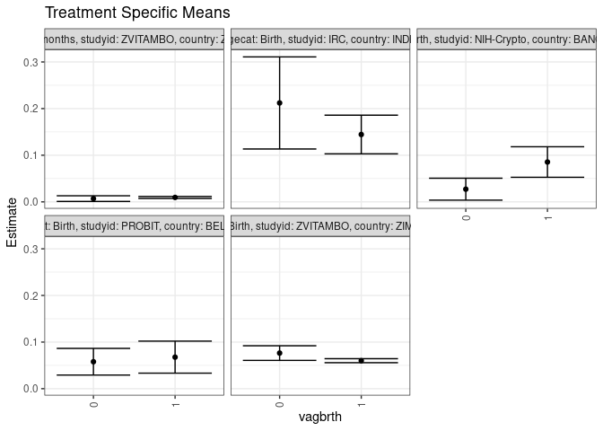

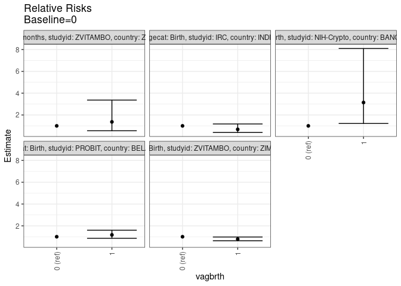

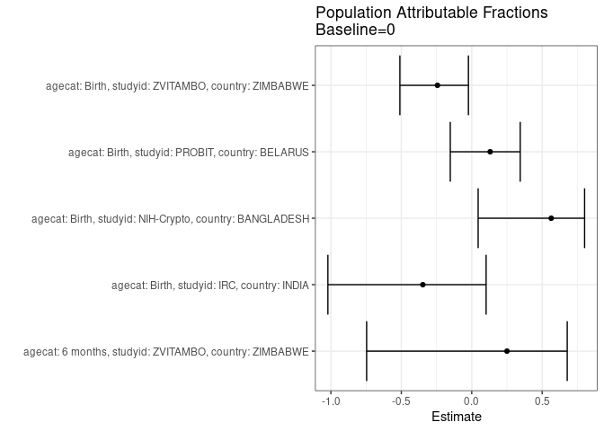

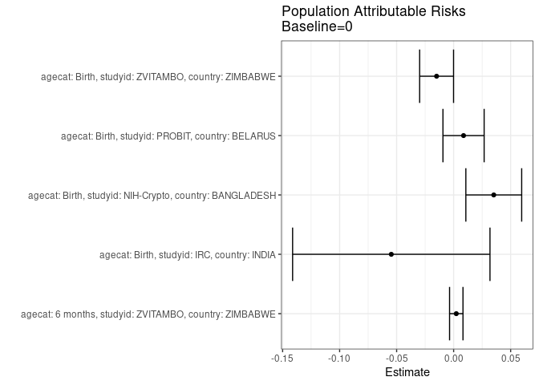

## Results Table

### Parameter: TSM

| agecat | studyid | country | intervention_level | baseline_level | estimate | ci_lower | ci_upper |
| --- | --- | --- | --- | --- | --- | --- | --- |
| Birth | IRC | INDIA | 0 | NA | 0.2121212 | 0.1133497 | 0.3108928 |
| Birth | IRC | INDIA | 1 | NA | 0.1444043 | 0.1029503 | 0.1858583 |
| Birth | NIH-Crypto | BANGLADESH | 0 | NA | 0.0271739 | 0.0036559 | 0.0506919 |
| Birth | NIH-Crypto | BANGLADESH | 1 | NA | 0.0854093 | 0.0526957 | 0.1181228 |
| Birth | PROBIT | BELARUS | 0 | NA | 0.0578253 | 0.0292477 | 0.0864029 |
| Birth | PROBIT | BELARUS | 1 | NA | 0.0676427 | 0.0332918 | 0.1019936 |
| Birth | ZVITAMBO | ZIMBABWE | 0 | NA | 0.0763636 | 0.0606686 | 0.0920587 |
| Birth | ZVITAMBO | ZIMBABWE | 1 | NA | 0.0600137 | 0.0557124 | 0.0643149 |
| 6 months | ZVITAMBO | ZIMBABWE | 0 | NA | 0.0069348 | 0.0008770 | 0.0129926 |
| 6 months | ZVITAMBO | ZIMBABWE | 1 | NA | 0.0094609 | 0.0073007 | 0.0116210 |

### Parameter: E(Y)

| agecat | studyid | country | intervention_level | baseline_level | estimate | ci_lower | ci_upper |
| --- | --- | --- | --- | --- | --- | --- | --- |
| Birth | IRC | INDIA | NA | NA | 0.1574344 | 0.1188345 | 0.1960344 |
| Birth | NIH-Crypto | BANGLADESH | NA | NA | 0.0623656 | 0.0403628 | 0.0843684 |
| Birth | PROBIT | BELARUS | NA | NA | 0.0665123 | 0.0333611 | 0.0996634 |
| Birth | ZVITAMBO | ZIMBABWE | NA | NA | 0.0614172 | 0.0572600 | 0.0655744 |
| 6 months | ZVITAMBO | ZIMBABWE | NA | NA | 0.0092450 | 0.0072027 | 0.0112873 |

### Parameter: RR

| agecat | studyid | country | intervention_level | baseline_level | estimate | ci_lower | ci_upper |
| --- | --- | --- | --- | --- | --- | --- | --- |
| Birth | IRC | INDIA | 0 | 0 | 1.0000000 | 1.0000000 | 1.0000000 |
| Birth | IRC | INDIA | 1 | 0 | 0.6807633 | 0.3939399 | 1.1764196 |
| Birth | NIH-Crypto | BANGLADESH | 0 | 0 | 1.0000000 | 1.0000000 | 1.0000000 |
| Birth | NIH-Crypto | BANGLADESH | 1 | 0 | 3.1430605 | 1.2198971 | 8.0980841 |
| Birth | PROBIT | BELARUS | 0 | 0 | 1.0000000 | 1.0000000 | 1.0000000 |
| Birth | PROBIT | BELARUS | 1 | 0 | 1.1697781 | 0.8554719 | 1.5995625 |
| Birth | ZVITAMBO | ZIMBABWE | 0 | 0 | 1.0000000 | 1.0000000 | 1.0000000 |
| Birth | ZVITAMBO | ZIMBABWE | 1 | 0 | 0.7858932 | 0.6321662 | 0.9770026 |
| 6 months | ZVITAMBO | ZIMBABWE | 0 | 0 | 1.0000000 | 1.0000000 | 1.0000000 |
| 6 months | ZVITAMBO | ZIMBABWE | 1 | 0 | 1.3642561 | 0.5530721 | 3.3651933 |

### Parameter: PAR

| agecat | studyid | country | intervention_level | baseline_level | estimate | ci_lower | ci_upper |
| --- | --- | --- | --- | --- | --- | --- | --- |
| Birth | IRC | INDIA | 0 | NA | -0.0546868 | -0.1412394 | 0.0318658 |
| Birth | NIH-Crypto | BANGLADESH | 0 | NA | 0.0351917 | 0.0107070 | 0.0596764 |
| Birth | PROBIT | BELARUS | 0 | NA | 0.0086870 | -0.0093769 | 0.0267509 |
| Birth | ZVITAMBO | ZIMBABWE | 0 | NA | -0.0149464 | -0.0298234 | -0.0000695 |
| 6 months | ZVITAMBO | ZIMBABWE | 0 | NA | 0.0023102 | -0.0035716 | 0.0081920 |

### Parameter: PAF

| agecat | studyid | country | intervention_level | baseline_level | estimate | ci_lower | ci_upper |
| --- | --- | --- | --- | --- | --- | --- | --- |
| Birth | IRC | INDIA | 0 | NA | -0.3473625 | -1.0213073 | 0.1018754 |
| Birth | NIH-Crypto | BANGLADESH | 0 | NA | 0.5642804 | 0.0453422 | 0.8011313 |
| Birth | PROBIT | BELARUS | 0 | NA | 0.1306075 | -0.1524088 | 0.3441187 |
| Birth | ZVITAMBO | ZIMBABWE | 0 | NA | -0.2433591 | -0.5102221 | -0.0236520 |
| 6 months | ZVITAMBO | ZIMBABWE | 0 | NA | 0.2498844 | -0.7462542 | 0.6777827 |